# Tugas 3

Azizah

2023-09-18

## Impor Data

```r
datacoba <- rio::import("https://raw.githubusercontent.com/azizahaa/MPDW-Prak/main/P2/Data%20Tugas%202.csv")
str(datacoba)
```

```
## 'data.frame':    1440 obs. of  4 variables:
##  $ Time       : POSIXct, format: "2020-03-21 00:00:00" "2020-03-21 00:10:00" ...
##  $ ActivePower: num  581 501 588 734 652 ...
##  $ RotorRPM   : num  119 103 118 150 132 ...
##  $ WindSpeed  : num  6.63 6.18 6.45 7.08 6.49 ...
```

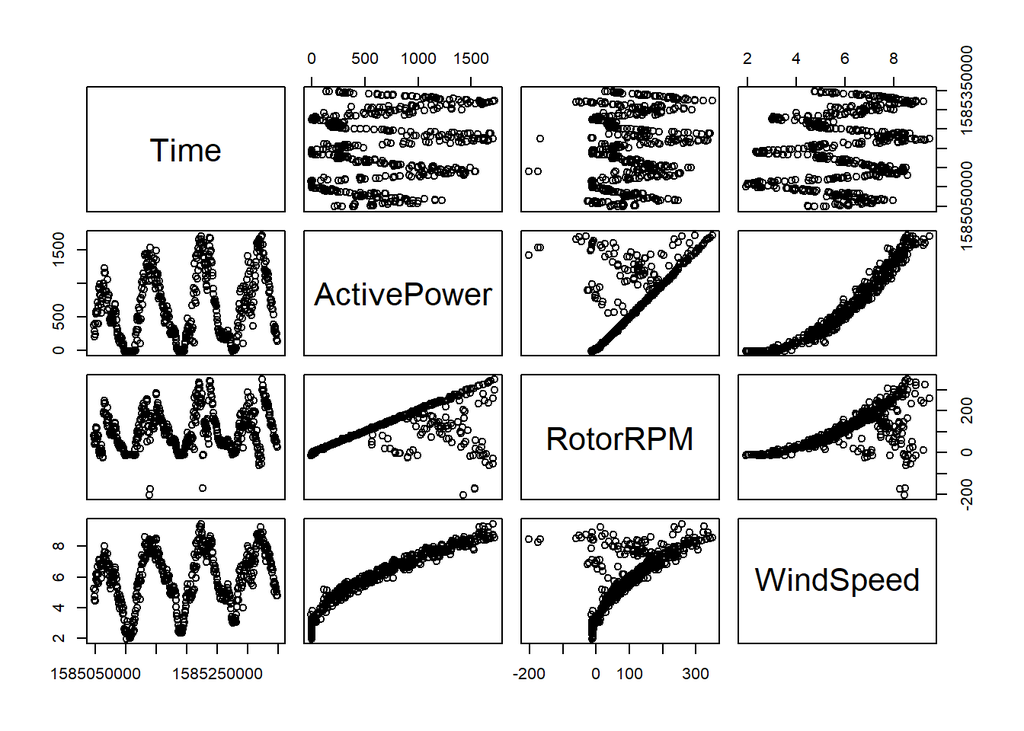

```r
plot(datacoba[500:1000,])
```

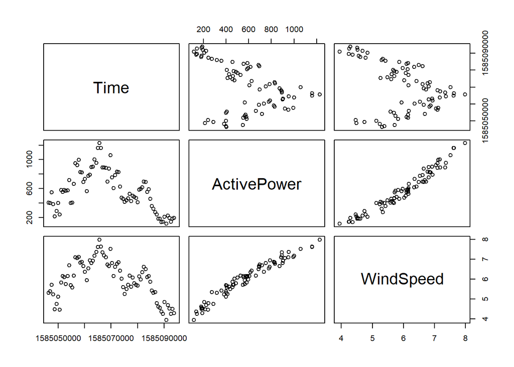

```r
b<-144*3
data3<-datacoba[497:576,c(1,2,4)]
plot(data3)
```

## Pembagian Data

Data kemudian dibagi menjadi data train dan data test degan perbandingan 4:1. Data train adalah 80% dari data, sedangkan data test adalah 20% dari data

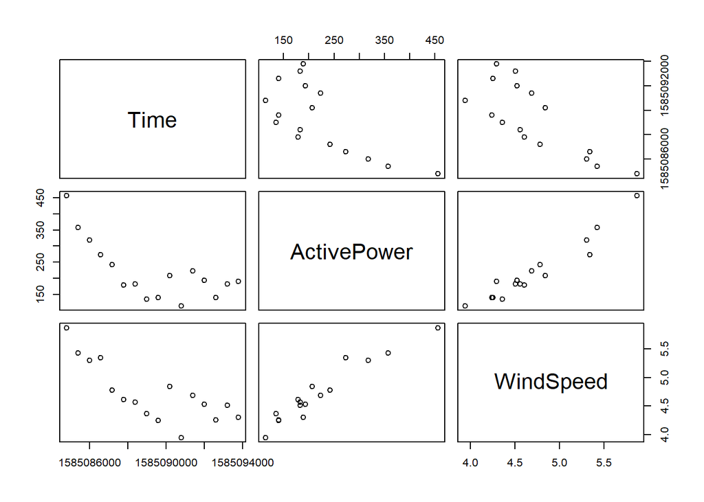

```r
#SPLIT DATA
b<-round(nrow(data3)*0.8)
w<-round(nrow(data3)*0.2)
train3<-data3[1:b,]
test3<-data3[(b+1):nrow(data3),]
plot(test3)
```

Data kemudian dibuat menjadi data timeseries

```r
#data time series
train3.ts<-ts(train3)
test3.ts<-ts(test3)
data3.ts<-ts(data3)
```

## Model Koyck

Model Koyck didasarkan pada asumsi bahwa semakin jauh jarak lag peubah independen dari periode sekarang maka semakin kecil pengaruh peubah lag terhadap peubah dependen.

Koyck mengusulkan suatu metode untuk menduga model dinamis distributed lag dengan mengasumsikan bahwa semua koefisien $\beta$ mempunyai tanda sama.

Model kyock merupakan jenis paling umum dari model infinite distributed lag dan juga dikenal sebagai geometric lag

$$y_t=a(1-\lambda)+\beta_0X_t+\beta_1Z_t+\lambda Y_{t-1}+V_t$$

dengan
$$V_t=u_t-\lambda
u_{t-1}$$

### Pemodelan

Pemodelan model Koyck dengan `R` dapat menggunakan `dLagM::koyckDlm()` . Fungsi umum dari `koyckDlm` adalah sebagai berikut.

```r
koyckDlm(x , y , intercept)
```

Fungsi `koyckDlm()` akan menerapkan model lag terdistribusi dengan transformasi Koyck satu prediktor. Nilai `x` dan `y` tidak perlu sebagai objek *time series* (`ts`). `intercept` dapat dibuat `TRUE` untuk memasukkan intersep ke dalam model.

```r
#MODEL KOYCK
model.koyck <- koyckDlm(x = train3$WindSpeed, y = train3$ActivePower)
summary(model.koyck)
```

```
##
## Call:
## "Y ~ (Intercept) + Y.1 + X.t"
##
## Residuals:
##     Min      1Q  Median      3Q     Max
## -421.56 -115.69   12.99  105.38  402.62
##
## Coefficients:
##             Estimate Std. Error t value Pr(>|t|)
## (Intercept)  781.733   2361.216   0.331    0.742
## Y.1            1.224      1.465   0.835    0.407
## X.t         -147.007    527.974  -0.278    0.782
##
## Residual standard error: 189.3 on 60 degrees of freedom
## Multiple R-Squared: 0.3624,  Adjusted R-squared: 0.3411
## Wald test:    32 on 2 and 60 DF,  p-value: 3.484e-10
##
## Diagnostic tests:
## NULL
##
##                              alpha      beta      phi
## Geometric coefficients:  -3495.737 -147.0074 1.223625
```

```r
AIC(model.koyck)
```

```
## [1] 844.3767
```

```r
BIC(model.koyck)
```

```
## [1] 852.9493
```

### Peramalan dan Akurasi

Berikut adalah hasil peramalan y untuk 16 periode kedepan menggunakan model koyck

```r
fore.koyck <- forecast(model = model.koyck, x=test3$WindSpeed, h=w)
fore.koyck
```

```
## $forecasts
##  [1]   637.3416   764.2995   937.4071  1143.5541  1478.2250  1913.3036
##  [7]  2452.2705  3141.4774  4002.4314  4967.5792  6280.9319  7778.1911
## [13]  9634.0553 11944.4694 14734.7313 18179.8990
##
## $call
## forecast.koyckDlm(model = model.koyck, x = test3$WindSpeed, h = w)
##
## attr(,"class")
## [1] "forecast.koyckDlm" "dLagM"
```

```r
mape.koyck <- MAPE(fore.koyck$forecasts, test3$ActivePower)
#akurasi data training
GoF(model.koyck)
```

```
##              n     MAE         MPE      MAPE     sMAPE     MASE     MSE
## model.koyck 63 144.605 -0.07833109 0.2632458 0.2353359 1.380343 34130.4
##                 MRAE    GMRAE
## model.koyck 19.26131 1.664251
```

## Regression with Distributed Lag

Pemodelan model Regression with Distributed Lag dengan `R` dapat menggunakan `dLagM::dlm()` . Fungsi umum dari `dlm` adalah sebagai berikut.

```r
dlm(formula , data , x , y , q , remove )
```

Fungsi `dlm()` akan menerapkan model lag terdistribusi dengan satu atau lebih prediktor. Nilai `x` dan `y` tidak perlu sebagai objek *time series* (`ts`). $q$ adalah integer yang mewakili panjang *lag* yang terbatas.

### Pemodelan (Lag=2)

```r
model.dlm <- dlm(x = train3$WindSpeed,y = train3$ActivePower , q = 2)
summary(model.dlm)
```

```
##
## Call:
## lm(formula = model.formula, data = design)
##
## Residuals:
##      Min       1Q   Median       3Q      Max
## -111.156  -51.990   -3.366   44.867  125.380
##
## Coefficients:
##              Estimate Std. Error t value Pr(>|t|)
## (Intercept) -1171.134     73.129 -16.015   <2e-16 ***
## x.t           310.013     19.339  16.031   <2e-16 ***
## x.1           -22.964     25.294  -0.908    0.368
## x.2             4.271     19.080   0.224    0.824
## ---
## Signif. codes:  0 '***' 0.001 '**' 0.01 '*' 0.05 '.' 0.1 ' ' 1
##
## Residual standard error: 63.75 on 58 degrees of freedom
## Multiple R-squared:  0.9285, Adjusted R-squared:  0.9248
## F-statistic: 251.2 on 3 and 58 DF,  p-value: < 2.2e-16
##
## AIC and BIC values for the model:
##        AIC     BIC
## 1 697.0393 707.675
```

```r
AIC(model.dlm)
```

```
## [1] 697.0393
```

```r
BIC(model.dlm)
```

```
## [1] 707.675
```

Dari hasil diatas, didapat bahwa $P-value$ dari intercept dan $x_{t}<0.05$. Hal ini menunjukkan bahwa intercept dan $x_{t}$ berpengaruh signifikan terhadap $y$. Adapun model keseluruhan yang terbentuk adalah sebagai berikut

$$\hat{Y_t}=-1171.134+310.013 X_t-22.964X_{t-1}+4.271X_{t-2}$$

### Peramalan dan Akurasi

Berikut merupakan hasil peramalan $y$ untuk 16 periode kedepan

```r
fore.dlm <- forecast(model = model.dlm, x=test3$WindSpeed, h=w)
fore.dlm
```

```
## $forecasts
##  [1] 533.75977 401.67488 373.30832 386.13354 210.91296 170.03684 157.73095
##  [8]  95.35721  62.64252 250.81899 -42.64541 212.13024 140.98439  64.52111
## [15] 147.64840  75.51346
##
## $call
## forecast.dlm(model = model.dlm, x = test3$WindSpeed, h = w)
##
## attr(,"class")
## [1] "forecast.dlm" "dLagM"
```

```r
mape.dlm <- MAPE(fore.dlm$forecasts, test3$ActivePower)
#akurasi data training
GoF(model.dlm)
```

```
##            n      MAE         MPE       MAPE    sMAPE      MASE      MSE
## model.dlm 62 52.82489 0.001674768 0.09436932 0.098299 0.5078134 3802.456
##               MRAE     GMRAE
## model.dlm 8.166098 0.7690344
```

### *Lag* Optimum

```r
#penentuan lag optimum
finiteDLMauto(formula = ActivePower ~ WindSpeed,
              data = data.frame(train3), q.max=30, model.type = "dlm", error.type = "AIC", trace = FALSE)
```

```
##    q - k    MASE      AIC      BIC   GMRAE   MBRAE R.Adj.Sq    Ljung-Box
## 30    30 0.07799 309.9328 360.3027 0.13053 0.23324  0.97636 8.429798e-06
```

Berdasarkan output tersebut, lag optimum didapatkan ketika lag=30. Selanjutnya dilakukan pemodelan untuk lag=30

```r
#model dlm dengan lag optimum
model.dlm2 <- dlm(x = train3$WindSpeed,y = train3$ActivePower , q = 30)
summary(model.dlm2)
```

```
##
## Call:
## lm(formula = model.formula, data = design)
##
## Residuals:
##        1        2        3        4        5        6        7        8
##  -2.2787  -4.7065   1.7547   5.2950   6.7327 -14.3617   7.6172  -2.8563
##        9       10       11       12       13       14       15       16
##  -6.2430  12.3175 -11.6054   1.6848   2.7542  -8.1650  13.9790  -8.0556
##       17       18       19       20       21       22       23       24
##   6.9287 -14.2677  21.0622 -12.1241   8.9089  -9.4160   9.5716  -5.4235
##       25       26       27       28       29       30       31       32
##  10.0858 -13.2890  -0.7228   2.6066  -2.0737  -4.2363  -4.4020   8.0983
##       33       34
##  -1.0846   5.9144
##
## Coefficients:
##               Estimate Std. Error t value Pr(>|t|)
## (Intercept) -1093.1118  2119.7965  -0.516   0.6574
## x.t           281.7280    65.2424   4.318   0.0497 *
## x.1            -4.3620    43.5466  -0.100   0.9293
## x.2           -40.1572    32.1552  -1.249   0.3381
## x.3            26.7814    33.9030   0.790   0.5123
## x.4            21.4679    46.2161   0.465   0.6879
## x.5            73.4623    36.0082   2.040   0.1781
## x.6             0.1297    41.8539   0.003   0.9978
## x.7           -12.5089    34.0059  -0.368   0.7483
## x.8           -54.9341    32.7466  -1.678   0.2354
## x.9           -22.2313    39.6802  -0.560   0.6317
## x.10           63.6917    29.4303   2.164   0.1629
## x.11          -14.2986    32.3036  -0.443   0.7013
## x.12          -41.2401    38.7426  -1.064   0.3986
## x.13           50.5126    61.8727   0.816   0.5000
## x.14          -21.6344    34.5896  -0.625   0.5955
## x.15           20.9050    35.3382   0.592   0.6141
## x.16           36.4339    37.9892   0.959   0.4387
## x.17         -113.4134    41.5359  -2.730   0.1120
## x.18          -11.7316    34.4762  -0.340   0.7661
## x.19           16.9319    45.9236   0.369   0.7477
## x.20           24.1838    39.9417   0.605   0.6064
## x.21           -2.0527    30.5147  -0.067   0.9525
## x.22           56.4465    33.3925   1.690   0.2330
## x.23          -58.1255    28.9293  -2.009   0.1823
## x.24          -68.2422    36.4713  -1.871   0.2022
## x.25           95.1538    42.2730   2.251   0.1533
## x.26          -32.9724    45.6582  -0.722   0.5452
## x.27          -15.9779    30.9227  -0.517   0.6568
## x.28           12.1435    33.1030   0.367   0.7489
## x.29          -66.2870    39.5764  -1.675   0.2359
## x.30           79.7673    26.6712   2.991   0.0960 .
## ---
## Signif. codes:  0 '***' 0.001 '**' 0.01 '*' 0.05 '.' 0.1 ' ' 1
##
## Residual standard error: 36.05 on 2 degrees of freedom
## Multiple R-squared:  0.9986, Adjusted R-squared:  0.9764
## F-statistic: 44.96 on 31 and 2 DF,  p-value: 0.02198
##
## AIC and BIC values for the model:
##        AIC      BIC
## 1 309.9328 360.3027
```

```r
AIC(model.dlm2)
```

```
## [1] 309.9328
```

```r
BIC(model.dlm2)
```

```
## [1] 360.3027
```

Dari hasil tersebut terdapat beberapa peubah yang berpengaruh signifikan terhadap taraf nyata 5% yaitu $x_t$. Adapun keseluruhan model yang terbentuk adalah

$$\hat{Y_t}=-1093.1118+281.7280X_t+...+79.7673X_{t-30}$$

Adapun hasil peramalan 16 periode kedepan menggunakan model tersebut adalah sebagai berikut

```r
#peramalan dan akurasi
fore.dlm2 <- forecast(model = model.dlm2, x=test3$WindSpeed, h=w)
mape.dlm2<- MAPE(fore.dlm2$forecasts, test3$ActivePower)
#akurasi data training
GoF(model.dlm2)
```

```
##             n      MAE          MPE       MAPE      sMAPE      MASE      MSE
## model.dlm2 34 7.371276 8.613995e-05 0.01235095 0.01236812 0.0779901 76.44847
##                MRAE     GMRAE
## model.dlm2 6.506293 0.1305346
```

Model tersebut merupakan model yang sangat baik dengan nilai MAPE yang kurang dari 10%.

## Model Autoregressive

Peubah dependen dipengaruhi oleh peubah independen pada waktu sekarang, serta dipengaruhi juga oleh peubah dependen itu sendiri pada satu waktu yang lalu maka model tersebut disebut *autoregressive* (Gujarati 2004).

### Pemodelan

Pemodelan Autoregressive dilakukan menggunakan fungsi `dLagM::ardlDlm()` . Fungsi tersebut akan menerapkan *autoregressive* berordo $(p,q)$ dengan satu prediktor. Fungsi umum dari `ardlDlm()` adalah sebagai berikut.

```r
ardlDlm(formula = NULL , data = NULL , x = NULL , y = NULL , p = 1 , q = 1 ,
         remove = NULL )
```

Dengan $p$ adalah integer yang mewakili panjang *lag* yang terbatas dan $q$ adalah integer yang merepresentasikan ordo dari proses *autoregressive*.

```r
model.ardl <- ardlDlm(x = train3$WindSpeed, y = train3$ActivePower, p = 1,q=1)
summary(model.ardl)
```

```
##
## Time series regression with "ts" data:
## Start = 2, End = 64
##
## Call:
## dynlm(formula = as.formula(model.text), data = data, start = 1)
##
## Residuals:
##      Min       1Q   Median       3Q      Max
## -104.414  -44.047   -2.207   40.026  136.823
##
## Coefficients:
##              Estimate Std. Error t value Pr(>|t|)
## (Intercept) -785.8903   172.2869  -4.562 2.62e-05 ***
## X.t          295.8299    19.2180  15.393  < 2e-16 ***
## X.1          -98.4177    37.6627  -2.613   0.0114 *
## Y.1            0.3103     0.1295   2.396   0.0197 *
## ---
## Signif. codes:  0 '***' 0.001 '**' 0.01 '*' 0.05 '.' 0.1 ' ' 1
##
## Residual standard error: 60.37 on 59 degrees of freedom
## Multiple R-squared:  0.9362, Adjusted R-squared:  0.933
## F-statistic: 288.7 on 3 and 59 DF,  p-value: < 2.2e-16
```

```r
AIC(model.ardl)
```

```
## [1] 701.3166
```

```r
BIC(model.ardl)
```

```
## [1] 712.0323
```

$$\hat{Y}=-785.8903+295.8299X_t-98.4177X_{t-1}+0.3103Y_{t-1}$$

### Peramalan dan Akurasi(BELUM)

```r
fore.ardl <- forecast(model = model.ardl, x=test3$WindSpeed, h=w)
fore.ardl
```

```
## $forecasts
##  [1] 527.99638 404.62142 374.61084 388.60059 223.27831 175.70559 164.78986
##  [8] 106.02252  72.21354 251.28427 -18.66654 207.12009 155.82972  76.28009
## [15] 152.15041  88.79567
##
## $call
## forecast.ardlDlm(model = model.ardl, x = test3$WindSpeed, h = w)
##
## attr(,"class")
## [1] "forecast.ardlDlm" "dLagM"
```

Data di atas merupakan hasil peramalan untuk 16 periode ke depan menggunakan Model Autoregressive dengan $p=1$ dan $q=1$.

```r
mape.ardl <- MAPE(fore.ardl$forecasts, test3$ActivePower)
mape.ardl
```

```
## [1] 0.2866697
```

```r
#akurasi data training
GoF(model.ardl)
```

```
##             n      MAE           MPE       MAPE      sMAPE      MASE     MSE
## model.ardl 63 47.58723 -0.0003187451 0.08134068 0.08276036 0.4542492 3413.19
##               MRAE     GMRAE
## model.ardl 1.84588 0.6123248
```

### *Lag* Optimum

```r
#penentuan lag optimum
model.ardl.opt <- ardlBoundOrders(data = data.frame(data3), ic = "AIC",
                                  formula = ActivePower ~ WindSpeed )
min_p=c()
for(i in 1:15){
  min_p[i]=min(model.ardl.opt$Stat.table[[i]])
}
q_opt=which(min_p==min(min_p, na.rm = TRUE))
p_opt=which(model.ardl.opt$Stat.table[[q_opt]] ==
              min(model.ardl.opt$Stat.table[[q_opt]], na.rm = TRUE))
data.frame("q_optimum" = q_opt, "p_optimum" = p_opt,
           "AIC"=model.ardl.opt$min.Stat)
```

```
##   q_optimum p_optimum      AIC
## 1        15         2 724.9315
```

Selanjutnya dapat dilakukan pemodelan dengan nilai $p$ dan $q$ optimum seperti inisialisasi di langkah sebelumnya.

```r
#Pemodelan dengan lag optimum
model.ardl2 <- ardlDlm(x = train3$WindSpeed, y = train3$ActivePower, p = 15,q=2)
summary(model.ardl2)
```

```
##
## Time series regression with "ts" data:
## Start = 16, End = 64
##
## Call:
## dynlm(formula = as.formula(model.text), data = data, start = 1)
##
## Residuals:
##      Min       1Q   Median       3Q      Max
## -123.538  -37.376   -2.886   23.354  125.626
##
## Coefficients:
##               Estimate Std. Error t value Pr(>|t|)
## (Intercept) -1.534e+03  4.605e+02  -3.331   0.0023 **
## X.t          3.468e+02  3.275e+01  10.589 1.19e-11 ***
## X.1         -1.019e+01  7.046e+01  -0.145   0.8859
## X.2          1.469e+01  6.762e+01   0.217   0.8295
## X.3         -7.132e+00  3.556e+01  -0.201   0.8424
## X.4          7.425e+00  3.647e+01   0.204   0.8400
## X.5          1.097e+00  3.863e+01   0.028   0.9775
## X.6          2.819e+01  3.937e+01   0.716   0.4795
## X.7         -1.984e+01  3.626e+01  -0.547   0.5884
## X.8          1.117e+01  3.248e+01   0.344   0.7332
## X.9         -3.596e+01  3.091e+01  -1.163   0.2539
## X.10         4.008e+01  3.146e+01   1.274   0.2125
## X.11        -6.213e-01  3.179e+01  -0.020   0.9845
## X.12         5.432e+00  3.203e+01   0.170   0.8665
## X.13        -1.564e+01  3.149e+01  -0.497   0.6231
## X.14        -2.153e+01  3.145e+01  -0.685   0.4989
## X.15         1.295e+01  2.364e+01   0.548   0.5880
## Y.1         -2.517e-02  2.045e-01  -0.123   0.9029
## Y.2         -7.245e-02  2.045e-01  -0.354   0.7257
## ---
## Signif. codes:  0 '***' 0.001 '**' 0.01 '*' 0.05 '.' 0.1 ' ' 1
##
## Residual standard error: 63.77 on 30 degrees of freedom
## Multiple R-squared:  0.9472, Adjusted R-squared:  0.9155
## F-statistic: 29.87 on 18 and 30 DF,  p-value: 2.284e-14
```

```r
AIC(model.ardl2)
```

```
## [1] 562.2284
```

```r
BIC(model.ardl2)
```

```
## [1] 600.0648
```

$$\hat{Y}=-1534+346.8X_t+....+-0.07245Y_{t-2}$$

```r
#Peramalan dan akurasi model kedua
fore.ardl2 <- forecast(model = model.ardl2, x=test3$WindSpeed, h=w)
fore.ardl2
```

```
## $forecasts
##  [1]  498.959989  370.324411  323.977560  352.225056  146.828814  107.243142
##  [7]   92.543051   24.056036  -25.458195  181.223615 -153.729177  121.556019
## [13]   51.167908  -25.855949   53.787186    3.781146
##
## $call
## forecast.ardlDlm(model = model.ardl2, x = test3$WindSpeed, h = w)
##
## attr(,"class")
## [1] "forecast.ardlDlm" "dLagM"
```

```r
mape.ardl2 <- MAPE(fore.ardl2$forecasts, test3$ActivePower)
mape.ardl2
```

```
## [1] 0.6410856
```

```r
#akurasi data training
GoF(model.ardl2)
```

```
##              n      MAE          MPE      MAPE      sMAPE      MASE      MSE
## model.ardl2 49 40.19057 -0.002249188 0.0606192 0.06130235 0.4038625 2489.518
##                 MRAE     GMRAE
## model.ardl2 8.547376 0.5765371
```

## Pemodelan DLM & ARDL dengan Library `dynlm`

Pemodelan regresi dengan peubah *lag* tidak hanya dapat dilakukan dengan fungsi pada *packages* `dLagM` , tetapi terdapat *packages* `dynlm` yang dapat digunakan. Fungsi `dynlm` secara umum adalah sebagai berikut.

```r
dynlm(formula, data, subset, weights, na.action, method = "qr",
  model = TRUE, x = FALSE, y = FALSE, qr = TRUE, singular.ok = TRUE,
  contrasts = NULL, offset, start = NULL, end = NULL, ...)
```

Untuk menentukan `formula` model yang akan digunakan, tersedia fungsi tambahan yang memungkinkan spesifikasi dinamika (melalui `d()` dan `L()`) atau pola linier/siklus dengan mudah (melalui `trend()`, `season()`, dan `harmon()`). Semua fungsi formula baru mengharuskan argumennya berupa objek deret waktu (yaitu, `"ts"` atau `"zoo"`).

```r
#sama dengan model dlm q=1
cons_lm1 <- dynlm(ActivePower ~ WindSpeed+L(WindSpeed),data = train3.ts)
#sama dengan model ardl p=1 q=0
cons_lm2 <- dynlm(ActivePower ~ WindSpeed+L(ActivePower),data = train3.ts)
#sama dengan ardl p=1 q=1
cons_lm3 <- dynlm(ActivePower ~ WindSpeed+L(WindSpeed)+L(ActivePower),data = train3.ts)
#sama dengan dlm p=2
cons_lm4 <- dynlm(ActivePower ~ WindSpeed+L(WindSpeed)+L(WindSpeed,2),data = train3.ts)
```

### Ringkasan Model

```r
summary(cons_lm1)
```

```
##
## Time series regression with "ts" data:
## Start = 2, End = 64
##
## Call:
## dynlm(formula = ActivePower ~ WindSpeed + L(WindSpeed), data = train3.ts)
##
## Residuals:
##      Min       1Q   Median       3Q      Max
## -109.131  -49.563   -2.045   42.024  123.047
##
## Coefficients:
##              Estimate Std. Error t value Pr(>|t|)
## (Intercept)  -1167.37      68.44 -17.057   <2e-16 ***
## WindSpeed      309.93      19.01  16.308   <2e-16 ***
## L(WindSpeed)   -19.22      18.76  -1.024     0.31
## ---
## Signif. codes:  0 '***' 0.001 '**' 0.01 '*' 0.05 '.' 0.1 ' ' 1
##
## Residual standard error: 62.71 on 60 degrees of freedom
## Multiple R-squared:   0.93,  Adjusted R-squared:  0.9277
## F-statistic: 398.7 on 2 and 60 DF,  p-value: < 2.2e-16
```

```r
summary(cons_lm2)
```

```
##
## Time series regression with "ts" data:
## Start = 2, End = 64
##
## Call:
## dynlm(formula = ActivePower ~ WindSpeed + L(ActivePower), data = train3.ts)
##
## Residuals:
##     Min      1Q  Median      3Q     Max
## -112.42  -52.19   -3.01   53.93  112.52
##
## Coefficients:
##                  Estimate Std. Error t value Pr(>|t|)
## (Intercept)    -1.172e+03  9.257e+01 -12.665   <2e-16 ***
## WindSpeed       2.901e+02  2.000e+01  14.507   <2e-16 ***
## L(ActivePower)  1.337e-02  6.504e-02   0.205    0.838
## ---
## Signif. codes:  0 '***' 0.001 '**' 0.01 '*' 0.05 '.' 0.1 ' ' 1
##
## Residual standard error: 63.23 on 60 degrees of freedom
## Multiple R-squared:  0.9289, Adjusted R-squared:  0.9265
## F-statistic: 391.7 on 2 and 60 DF,  p-value: < 2.2e-16
```

```r
summary(cons_lm3)
```

```
##
## Time series regression with "ts" data:
## Start = 2, End = 64
##
## Call:
## dynlm(formula = ActivePower ~ WindSpeed + L(WindSpeed) + L(ActivePower),
##     data = train3.ts)
##
## Residuals:
##      Min       1Q   Median       3Q      Max
## -104.414  -44.047   -2.207   40.026  136.823
##
## Coefficients:
##                 Estimate Std. Error t value Pr(>|t|)
## (Intercept)    -785.8903   172.2869  -4.562 2.62e-05 ***
## WindSpeed       295.8299    19.2180  15.393  < 2e-16 ***
## L(WindSpeed)    -98.4177    37.6627  -2.613   0.0114 *
## L(ActivePower)    0.3103     0.1295   2.396   0.0197 *
## ---
## Signif. codes:  0 '***' 0.001 '**' 0.01 '*' 0.05 '.' 0.1 ' ' 1
##
## Residual standard error: 60.37 on 59 degrees of freedom
## Multiple R-squared:  0.9362, Adjusted R-squared:  0.933
## F-statistic: 288.7 on 3 and 59 DF,  p-value: < 2.2e-16
```

```r
summary(cons_lm4)
```

```
##
## Time series regression with "ts" data:
## Start = 3, End = 64
##
## Call:
## dynlm(formula = ActivePower ~ WindSpeed + L(WindSpeed) + L(WindSpeed,
##     2), data = train3.ts)
##
## Residuals:
##      Min       1Q   Median       3Q      Max
## -111.156  -51.990   -3.366   44.867  125.380
##
## Coefficients:
##                  Estimate Std. Error t value Pr(>|t|)
## (Intercept)     -1171.134     73.129 -16.015   <2e-16 ***
## WindSpeed         310.013     19.339  16.031   <2e-16 ***
## L(WindSpeed)      -22.964     25.294  -0.908    0.368
## L(WindSpeed, 2)     4.271     19.080   0.224    0.824
## ---
## Signif. codes:  0 '***' 0.001 '**' 0.01 '*' 0.05 '.' 0.1 ' ' 1
##
## Residual standard error: 63.75 on 58 degrees of freedom
## Multiple R-squared:  0.9285, Adjusted R-squared:  0.9248
## F-statistic: 251.2 on 3 and 58 DF,  p-value: < 2.2e-16
```

### SSE

```r
deviance(cons_lm1)
```

```
## [1] 235960.3
```

```r
deviance(cons_lm2)
```

```
## [1] 239918
```

```r
deviance(cons_lm3)
```

```
## [1] 215030.9
```

```r
deviance(cons_lm4)
```

```
## [1] 235752.2
```

### Uji Diagnostik

```r
#uji model
if(require("lmtest")) encomptest(cons_lm1, cons_lm2)
```

```
## Encompassing test
##
## Model 1: ActivePower ~ WindSpeed + L(WindSpeed)
## Model 2: ActivePower ~ WindSpeed + L(ActivePower)
## Model E: ActivePower ~ WindSpeed + L(WindSpeed) + L(ActivePower)
##           Res.Df Df      F  Pr(>F)
## M1 vs. ME     59 -1 5.7426 0.01975 *
## M2 vs. ME     59 -1 6.8285 0.01136 *
## ---
## Signif. codes:  0 '***' 0.001 '**' 0.01 '*' 0.05 '.' 0.1 ' ' 1
```

#### Autokorelasi

```r
#durbin watson
dwtest(cons_lm1)
```

```
##
##  Durbin-Watson test
##
## data:  cons_lm1
## DW = 1.4153, p-value = 0.006401
## alternative hypothesis: true autocorrelation is greater than 0
```

```r
dwtest(cons_lm2)
```

```
##
##  Durbin-Watson test
##
## data:  cons_lm2
## DW = 1.3832, p-value = 0.004268
## alternative hypothesis: true autocorrelation is greater than 0
```

```r
dwtest(cons_lm3)
```

```
##
##  Durbin-Watson test
##
## data:  cons_lm3
## DW = 2.0348, p-value = 0.4926
## alternative hypothesis: true autocorrelation is greater than 0
```

```r
dwtest(cons_lm4)
```

```
##
##  Durbin-Watson test
##
## data:  cons_lm4
## DW = 1.4031, p-value = 0.006115
## alternative hypothesis: true autocorrelation is greater than 0
```

H0: Tidak berautokorelasi H1 : Ada autokorelasi

#### Heterogenitas

```r
bptest(cons_lm1)
```

```
##
##  studentized Breusch-Pagan test
##
## data:  cons_lm1
## BP = 1.1101, df = 2, p-value = 0.574
```

```r
bptest(cons_lm2)
```

```
##
##  studentized Breusch-Pagan test
##
## data:  cons_lm2
## BP = 1.8058, df = 2, p-value = 0.4054
```

```r
bptest(cons_lm3)
```

```
##
##  studentized Breusch-Pagan test
##
## data:  cons_lm3
## BP = 4.0068, df = 3, p-value = 0.2607
```

```r
bptest(cons_lm4)
```

```
##
##  studentized Breusch-Pagan test
##
## data:  cons_lm4
## BP = 1.1868, df = 3, p-value = 0.7562
```

H0 : homogen H1 : tidak homogen

#### Kenormalan

```r
shapiro.test(residuals(cons_lm1))
```

```
##
##  Shapiro-Wilk normality test
##
## data:  residuals(cons_lm1)
## W = 0.9693, p-value = 0.1167
```

```r
shapiro.test(residuals(cons_lm2))
```

```
##
##  Shapiro-Wilk normality test
##
## data:  residuals(cons_lm2)
## W = 0.96107, p-value = 0.04409
```

```r
shapiro.test(residuals(cons_lm3))
```

```
##
##  Shapiro-Wilk normality test
##
## data:  residuals(cons_lm3)
## W = 0.97512, p-value = 0.2305
```

```r
shapiro.test(residuals(cons_lm4))
```

```
##
##  Shapiro-Wilk normality test
##
## data:  residuals(cons_lm4)
## W = 0.96947, p-value = 0.1249
```

H0 : Data normal H1 : Data tidak menyebar normal

## Perbandingan Model

```r
akurasi <- matrix(c(mape.koyck, mape.dlm, mape.dlm2, mape.ardl,mape.ardl2))
row.names(akurasi)<- c("Koyck","DLM 1","DLM 2","Autoregressive 1","Autoregressive 2")
colnames(akurasi) <- c("MAPE")
akurasi
```

```
##                        MAPE
## Koyck            31.3283436
## DLM 1             0.3303544
## DLM 2             0.5440502
## Autoregressive 1  0.2866697
## Autoregressive 2  0.6410856
```

Berdasarkan nilai MAPE, model paling optimum didapat pada Model Autoregressive 1 karena memiliki nilai MAPE yang terkecil.

### Plot

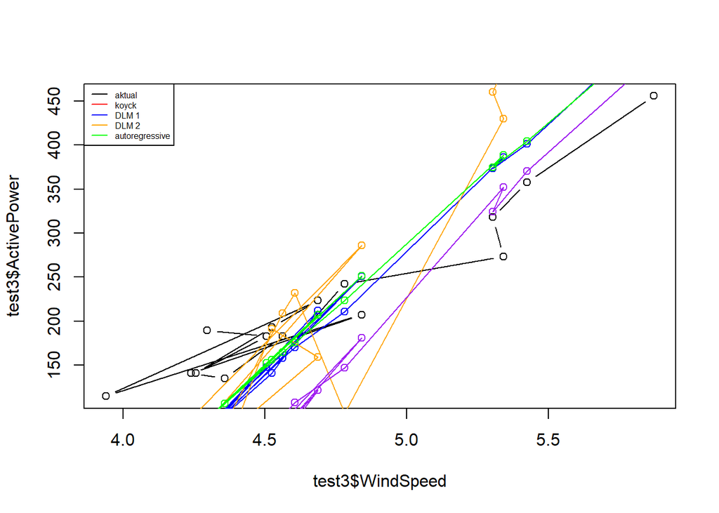

```r
par(mfrow=c(1,1))
plot(test3$WindSpeed, test3$ActivePower, type="b", col="black")
points(test3$WindSpeed, fore.koyck$forecasts,col="red")
lines(test3$WindSpeed, fore.koyck$forecasts,col="red")
points(test3$WindSpeed, fore.dlm$forecasts,col="blue")
lines(test3$WindSpeed, fore.dlm$forecasts,col="blue")
points(test3$WindSpeed, fore.dlm2$forecasts,col="orange")
lines(test3$WindSpeed, fore.dlm2$forecasts,col="orange")
points(test3$WindSpeed, fore.ardl$forecasts,col="green")
lines(test3$WindSpeed, fore.ardl$forecasts,col="green")
points(test3$WindSpeed, fore.ardl2$forecasts,col="purple")
lines(test3$WindSpeed, fore.ardl2$forecasts,col="purple")
legend("topleft",c("aktual", "koyck","DLM 1","DLM 2", "autoregressive"), lty=1, col=c("black","red","blue","orange","green","purple"), cex=0.5)
```

Berdasarkan plot tersebut, terlihat bahwa plot yang paling mendekati data aktualnya adalah Model Autoregressive 1, sehingga dapat disimpulkan model terbaik dalam hal ini adalah model regresiAutoregressive 1